# Kelompok13

Author

Kelompok 13

## Tim Penyusun

**Tip**

1. Bagas Febry Gunawan - X1005261001
2. Cindy Mayesra Azahra - M0501261062
3. Salvador Sarmento - M0501261801

## Penyelesaian Soal

### Soal 1. Pembersihan Data

Lakukan tahapan berikut.

1. Buat data frame bernama `nilai_raw` secara manual di R berdasarkan Tabel 1.
2. Identifikasi nilai yang hilang pada dataset secara sistematis. Ubah tanda hubung (`"-"`) pada nilai Statistika milik Dewi menjadi nilai hilang standar R, yaitu `NA`.
3. Lakukan imputasi terhadap nilai `Statistika` yang kosong menggunakan rata-rata nilai Statistika mahasiswa lainnya yang tersedia.
4. Buat kolom baru bernama `Status_Umur` menggunakan fungsi `ifelse()` dengan ketentuan:  
   `Dewasa` jika umur ≥ 21 tahun;  
   `Muda` jika umur < 21 tahun.
5. Identifikasi dan hapus baris pengamatan yang duplikat.
6. Simpan dataset yang telah dibersihkan ke dalam file bernama **`nilai_bersih.csv`**.

#### Penyelesaian

##### Poin 1

```r
nilai_raw <- data.frame(
  Nama = c("Andi", "Budi", "Citra", "Dewi", "Andi"),
  Matematika = c(80, 90, NA, 75, 80),
  Statistika = c(85, 88, 78, "-", 85),
  Umur = c(21, 20, 22, 21, 21)
)
nilai_raw
```

```
   Nama Matematika Statistika Umur
1  Andi         80         85   21
2  Budi         90         88   20
3 Citra         NA         78   22
4  Dewi         75          -   21
5  Andi         80         85   21
```

##### Poin 2

```r
nilai_raw$Statistika[nilai_raw$Statistika == "-"] <- NA
nilai_raw$Statistika <- as.numeric(nilai_raw$Statistika)
nilai_raw
```

```
   Nama Matematika Statistika Umur
1  Andi         80         85   21
2  Budi         90         88   20
3 Citra         NA         78   22
4  Dewi         75         NA   21
5  Andi         80         85   21
```

##### Poin 3

```r
nilai_raw$Statistika[is.na(nilai_raw$Statistika)] <- mean(nilai_raw$Statistika, na.rm = TRUE)

nilai_raw
```

```
   Nama Matematika Statistika Umur
1  Andi         80         85   21
2  Budi         90         88   20
3 Citra         NA         78   22
4  Dewi         75         84   21
5  Andi         80         85   21
```

##### Poin 4

```r
nilai_raw$Status_Umur <- ifelse(nilai_raw$Umur >= 21, "Dewasa", "Muda")

nilai_raw
```

```
   Nama Matematika Statistika Umur Status_Umur
1  Andi         80         85   21      Dewasa
2  Budi         90         88   20        Muda
3 Citra         NA         78   22      Dewasa
4  Dewi         75         84   21      Dewasa
5  Andi         80         85   21      Dewasa
```

##### Poin 5

```r
nilai_raw[duplicated(nilai_raw), ]
```

```
  Nama Matematika Statistika Umur Status_Umur
5 Andi         80         85   21      Dewasa
```

```r
nilai_bersih <- nilai_raw[!duplicated(nilai_raw), ]
nilai_bersih
```

```
   Nama Matematika Statistika Umur Status_Umur
1  Andi         80         85   21      Dewasa
2  Budi         90         88   20        Muda
3 Citra         NA         78   22      Dewasa
4  Dewi         75         84   21      Dewasa
```

##### Poin 6

```r
setwd(dir = "D:\\00. S2 SSD IPB\\Bahan Ajar\\SEM 1\\Pemrograman Statistika\\Praktikum\\4")
write.csv(nilai_bersih, "nilai_bersih.csv")
```

Link hasil export setelah diunggah di Github: nilai_bersih.csv

### Soal 2. Subsetting dan Pengurutan Multikriteria

Lakukan tahapan berikut.

1. Buat data frame bernama `profil` secara manual di R berdasarkan Tabel 2.
2. Lakukan penyaringan (subsetting) sehingga hanya menyisakan pengamatan yang memenuhi salah satu kondisi berikut:  
   gender laki-laki `(m)` dan `v1 > 9` ; atau  
   gender perempuan `(f)` dan `v3 <= 10`.
3. Urutkan data hasil penyaringan secara multikriteria, dengan ketentuan:  
   `gender` diurutkan secara *descending*;  
   untuk pengamatan dengan `gender` yang sama, `v5` diurutkan secara *ascending*.
4. Simpan hasil akhir ke dalam file bernama **`profil_filter.csv`**.

#### Penyelesaian

##### Poin 1

```r
profil<-data.frame(
  gender = c("f","f","f","m","m","f","m","m","f","m"),
  v1 = c(8,15,8,14,8,10,9,9,10,12),
  v2 = c(9,8,13,9,2,6,9,10,13,10),
  v3 = c(5,9,12,8,9,10,7,8,6,9),
  v4 = c(9,5,6,NA,16,9,13,10,7,8),
  v5 = c(9,10,7,11,8,10,9,5,10,17),
  v6 = c(9,8,9,10,10,10,12,10,12,7),
  v7 = c(5,10,14,6,8,9,10,6,13,9),
  v8 = c(9,12,12,11,9,7,9,12,9,10),
  v9 = c(11,9,12,11,8,7,11,6,6,7),
  v10 = c(8,15,9,8,9,11,7,8,9,7)
)
profil
```

```
   gender v1 v2 v3 v4 v5 v6 v7 v8 v9 v10
1       f  8  9  5  9  9  9  5  9 11   8
2       f 15  8  9  5 10  8 10 12  9  15
3       f  8 13 12  6  7  9 14 12 12   9
4       m 14  9  8 NA 11 10  6 11 11   8
5       m  8  2  9 16  8 10  8  9  8   9
6       f 10  6 10  9 10 10  9  7  7  11
7       m  9  9  7 13  9 12 10  9 11   7
8       m  9 10  8 10  5 10  6 12  6   8
9       f 10 13  6  7 10 12 13  9  6   9
10      m 12 10  9  8 17  7  9 10  7   7
```

##### Poin 2

```r
filter <- (profil$gender=="m" & profil$v1>9) | (profil$gender=="f" & profil$v3<=10)
subs<-profil[filter,]
subs
```

```
   gender v1 v2 v3 v4 v5 v6 v7 v8 v9 v10
1       f  8  9  5  9  9  9  5  9 11   8
2       f 15  8  9  5 10  8 10 12  9  15
4       m 14  9  8 NA 11 10  6 11 11   8
6       f 10  6 10  9 10 10  9  7  7  11
9       f 10 13  6  7 10 12 13  9  6   9
10      m 12 10  9  8 17  7  9 10  7   7
```

##### Poin 3

```r
urut<-order(subs$gender, subs$v5, decreasing = c(T,F),method = "radix")
terurut<-subs[urut,]
terurut
```

```
   gender v1 v2 v3 v4 v5 v6 v7 v8 v9 v10
4       m 14  9  8 NA 11 10  6 11 11   8
10      m 12 10  9  8 17  7  9 10  7   7
1       f  8  9  5  9  9  9  5  9 11   8
2       f 15  8  9  5 10  8 10 12  9  15
6       f 10  6 10  9 10 10  9  7  7  11
9       f 10 13  6  7 10 12 13  9  6   9
```

##### Poin 4

```r
setwd(dir = "D:\\00. S2 SSD IPB\\Bahan Ajar\\SEM 1\\Pemrograman Statistika\\Praktikum\\4")
write.csv(terurut,"profil_filter.csv")
```

Link hasil export setelah diunggah di Github: profil_filter.csv

### Soal 3. Penggabungan dan Reshaping Data

Diberikan dua data frame mengenai skor penjualan mingguan beberapa toko berikut.

```
df_sales <- data.frame(   id_toko = c("T1", "T2", "T3"),   Minggu1 = c(120, 150, 95),   Minggu2 = c(135, 140, 110) )  df_info <- data.frame(   id = c("T1", "T2", "T4"),   Kota = c("Jakarta", "Bandung", "Surabaya") )
```

Lakukan tahapan berikut.

1. Gabungkan `df_sales` dan `df_info` menggunakan fungsi `merge()` dengan metode Full Outer Join, sehingga seluruh toko dari kedua data frame tetap disertakan.  
   Perhatikan bahwa nama variabel kunci pada kedua data frame berbeda, yaitu `id_toko` pada `df_sales` dan `id` pada `df_info`. Gunakan argumen penggabungan yang sesuai.
2. Ubah struktur data hasil penggabungan dari format Wide menjadi Long, sehingga:  
   `Minggu1` dan `Minggu2` digabung menjadi satu kolom bernama `Waktu`;  
   nilai penjualan disimpan dalam satu kolom bernama `Penjualan`.

Simpan dataset dalam format Long tersebut ke dalam file bernama **`penjualan_long.csv`**.

#### Penyelesaian

##### Poin 1

```r
df_sales <- data.frame(
  id_toko = c("T1", "T2", "T3"),
  Minggu1 = c(120, 150, 95),
  Minggu2 = c(135, 140, 110)
)

df_info <- data.frame(
  id = c("T1", "T2", "T4"),
  Kota = c("Jakarta", "Bandung", "Surabaya")
)

df_merge<-merge(x = df_sales, y = df_info, by = 1, all = T)
row.names(df_merge)<-NULL
df_merge
```

```
  id_toko Minggu1 Minggu2     Kota
1      T1     120     135  Jakarta
2      T2     150     140  Bandung
3      T3      95     110     <NA>
4      T4      NA      NA Surabaya
```

##### Poin 2

```r
df_long<-reshape(data = df_merge,varying = c("Minggu1", "Minggu2"), v.names = "Penjualan", timevar = "Waktu", times = c("Minggu1", "Minggu2"), direction = "long")
row.names(df_long) <- NULL
df_long
```

```
  id_toko     Kota   Waktu Penjualan id
1      T1  Jakarta Minggu1       120  1
2      T2  Bandung Minggu1       150  2
3      T3     <NA> Minggu1        95  3
4      T4 Surabaya Minggu1        NA  4
5      T1  Jakarta Minggu2       135  1
6      T2  Bandung Minggu2       140  2
7      T3     <NA> Minggu2       110  3
8      T4 Surabaya Minggu2        NA  4
```

##### Poin 3

```r
write.csv(df_long,"penjualan_long.csv")
```

Link hasil export setelah diunggah di Github: penjualan_long.csv

### Soal 4. Eksplorasi Visual

Gunakan dataset bawaan R `CO2` untuk mengeksplorasi hubungan antara konsentrasi karbon dioksida (`conc`) dan tingkat penyerapan karbon dioksida (`uptake`) pada tanaman.

1. Kenali struktur dataset `CO2` dan identifikasi peran peubah `Plant`, `Type`, `Treatment`, `conc`, dan `uptake`, kemudian buat grafik menggunakan **base R** untuk menunjukkan hubungan `conc` dan `uptake` dengan mengatur bentuk dan ukuran titik, warna, judul, label sumbu, serta rentang sumbu, lalu tambahkan minimal **dua elemen grafik** menggunakan `points()`, `lines()`, `abline()`, atau `text()`.
2. Buat satu tampilan grafik berukuran **2 × 2** yang terdiri atas empat jenis visualisasi berbeda untuk mengeksplorasi `conc`, `uptake`, `Type`, dan `Treatment`; tentukan sendiri jenis grafik yang paling sesuai dan berikan judul yang jelas pada setiap grafik.
3. Gunakan `qplot()` untuk membuat visualisasi cepat hubungan `conc` dan `uptake` berdasarkan `Treatment`, kemudian buat kembali visualisasi tersebut menggunakan `ggplot2` dengan memetakan `Treatment` dan `Type` ke **atribut visual yang berbeda** di dalam `aes()` serta menggunakan `geom_*` yang sesuai.
4. Kembangkan grafik `ggplot2` tersebut dengan menambahkan minimal satu `stat_*`, satu `scale_*`, serta salah satu `coord_*`, kemudian lengkapi grafik menggunakan `labs()` dan `theme()` atau salah satu tema siap pakai agar grafik lebih informatif dan mudah dibaca.
5. Simpan grafik akhir menggunakan `ggsave()` dalam format PNG dengan nama **`co2_uptake_visualisasi.png`**, kemudian tuliskan interpretasi mengenai hubungan antara konsentrasi CO₂ dan `uptake` serta perbedaan pola yang terlihat berdasarkan `Type` dan `Treatment`.

#### Penyelesaian

##### Poin 1

```r
df<-CO2
str(df)
```

```
Classes 'nfnGroupedData', 'nfGroupedData', 'groupedData' and 'data.frame':  84 obs. of  5 variables:
 $ Plant    : Ord.factor w/ 12 levels "Qn1"<"Qn2"<"Qn3"<..: 1 1 1 1 1 1 1 2 2 2 ...
 $ Type     : Factor w/ 2 levels "Quebec","Mississippi": 1 1 1 1 1 1 1 1 1 1 ...
 $ Treatment: Factor w/ 2 levels "nonchilled","chilled": 1 1 1 1 1 1 1 1 1 1 ...
 $ conc     : num  95 175 250 350 500 675 1000 95 175 250 ...
 $ uptake   : num  16 30.4 34.8 37.2 35.3 39.2 39.7 13.6 27.3 37.1 ...
 - attr(*, "formula")=Class 'formula'  language uptake ~ conc | Plant
  .. ..- attr(*, ".Environment")=<environment: R_EmptyEnv>
 - attr(*, "outer")=Class 'formula'  language ~Treatment * Type
  .. ..- attr(*, ".Environment")=<environment: R_EmptyEnv>
 - attr(*, "labels")=List of 2
  ..$ x: chr "Ambient carbon dioxide concentration"
  ..$ y: chr "CO2 uptake rate"
 - attr(*, "units")=List of 2
  ..$ x: chr "(uL/L)"
  ..$ y: chr "(umol/m^2 s)"
```

```r
head(df)
```

```
  Plant   Type  Treatment conc uptake
1   Qn1 Quebec nonchilled   95   16.0
2   Qn1 Quebec nonchilled  175   30.4
3   Qn1 Quebec nonchilled  250   34.8
4   Qn1 Quebec nonchilled  350   37.2
5   Qn1 Quebec nonchilled  500   35.3
6   Qn1 Quebec nonchilled  675   39.2
```

```r
summary(df$uptake)
```

```
   Min. 1st Qu.  Median    Mean 3rd Qu.    Max.
   7.70   17.90   28.30   27.21   37.12   45.50
```

```r
summary(df$conc)
```

```
   Min. 1st Qu.  Median    Mean 3rd Qu.    Max.
     95     175     350     435     675    1000
```

Berdasarkan `str(df)` dan `head(df)` , kita dapat langsung mengidentifikasi struktur data dari `data.frame (df)` , dimana `df` terdiri dari 5 kolom, diantaranya:

1. Plant: Memiliki tipe data Ordinal Factor dengan 12 level –> Jenis/kode tanaman
2. Type: Memiliki tipe data Factor dengan 2 level –> Tipe tanaman
3. Treatment: Memiliki tipe data Factor dengan 2 level –> Jenis treatment
4. conc: Memiliki tipe data numeric –> Konsentrasi CO2
5. uptake: Memiliki tipe data numeric –> Uptake CO2 hasil pengamatan

Identifikasi lebih lanjut dari peubah `conc` dan `uptake` yang memiliki tipe data numeric, dapat dilakukan dengan menggunakan fungsi `summary()`.

```r
plot(x = df$conc, y = df$uptake, type = "p", xlab = "Ambient CO2 Concentration", ylab = "CO2 Uptake Rate",
     main = "Pengaruh konsentrasi CO2 terhadap CO2 uptake", pch=8, cex=1.2, col="seagreen",
     xlim = c(0,1000), ylim = c(0,50), axes = F, frame.plot = T)
meanuptake<-tapply(df$uptake, df$conc, mean)
unique(df$conc)
```

```
[1]   95  175  250  350  500  675 1000
```

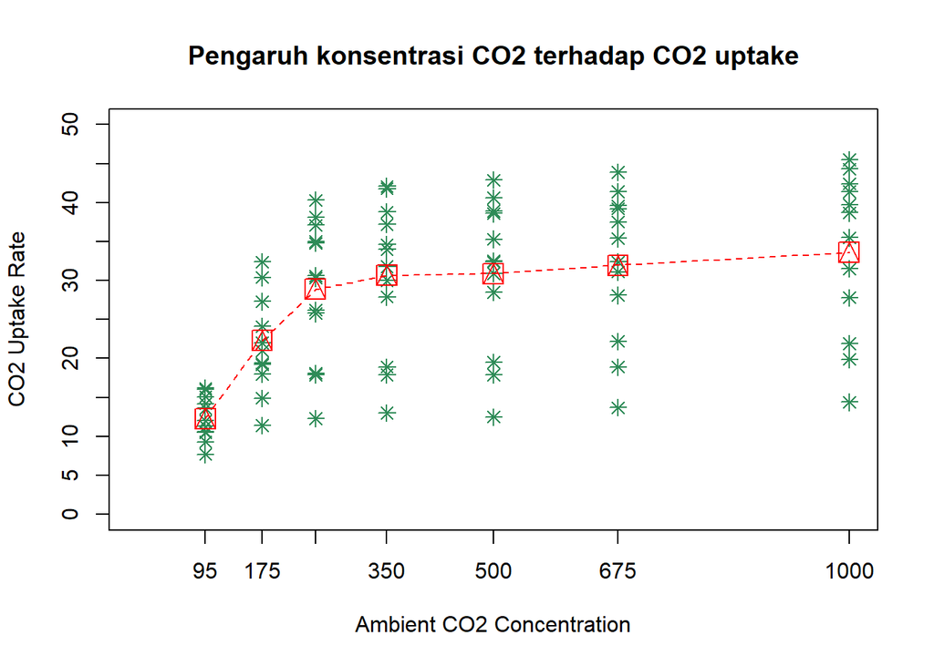

```r
axis(1,unique(df$conc))
axis(2,seq(0,50, by=5))
points(unique(df$conc), meanuptake, pch=14, cex=2,col="red")
lines(unique(df$conc), meanuptake, lty=2, col="red")
```

##### Poin 2

Set parameter 2 x 2

```r
par(mfrow=c(2,2))
```

Plot 1,1

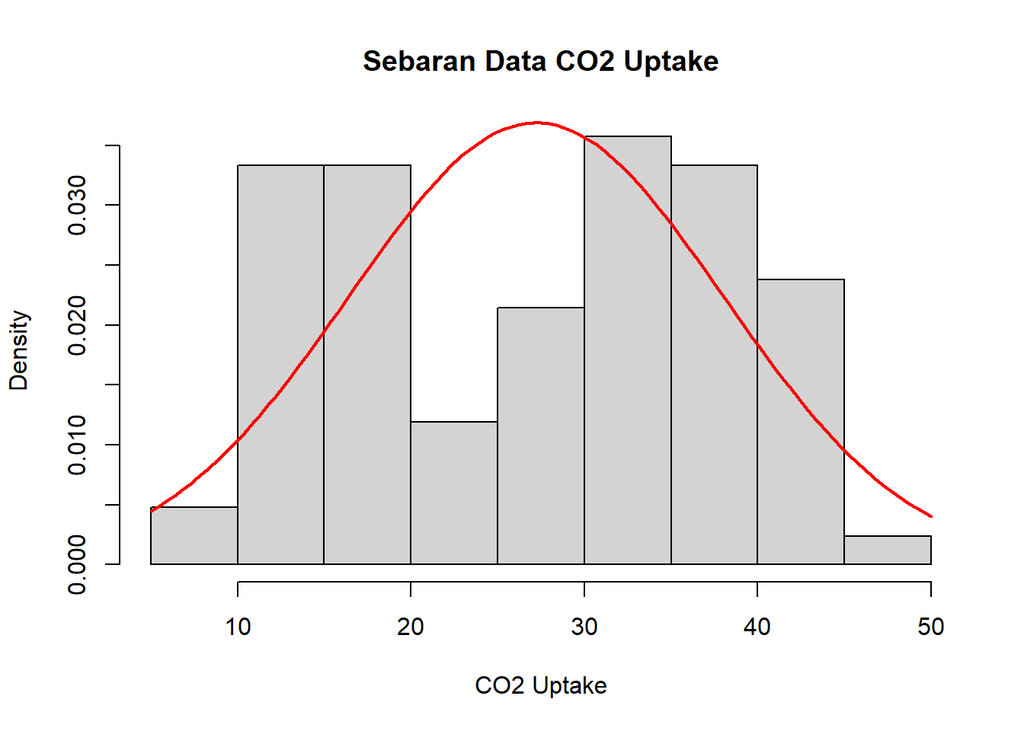

```r
hist(x = df$uptake, freq = F, main = "Sebaran Data CO2 Uptake", xlab = "CO2 Uptake")
curve(dnorm(x, mean = mean(df$uptake), sd = sd(df$uptake)),
      add = TRUE, col = "red", lwd = 2)
```

Plot 1,2

```r
plot(x = df$conc, y = df$uptake, type = "p", xlab = "Ambient CO2 Concentration", ylab = "CO2 Uptake Rate",
     main = "Pengaruh konsentrasi CO2\nterhadap CO2 uptake", pch=8, cex=1.2, col="seagreen",
     xlim = c(0,1000), ylim = c(0,50), axes = F, frame.plot = T)
meanuptake<-tapply(df$uptake, df$conc, mean)
unique(df$conc)
```

```
[1]   95  175  250  350  500  675 1000
```

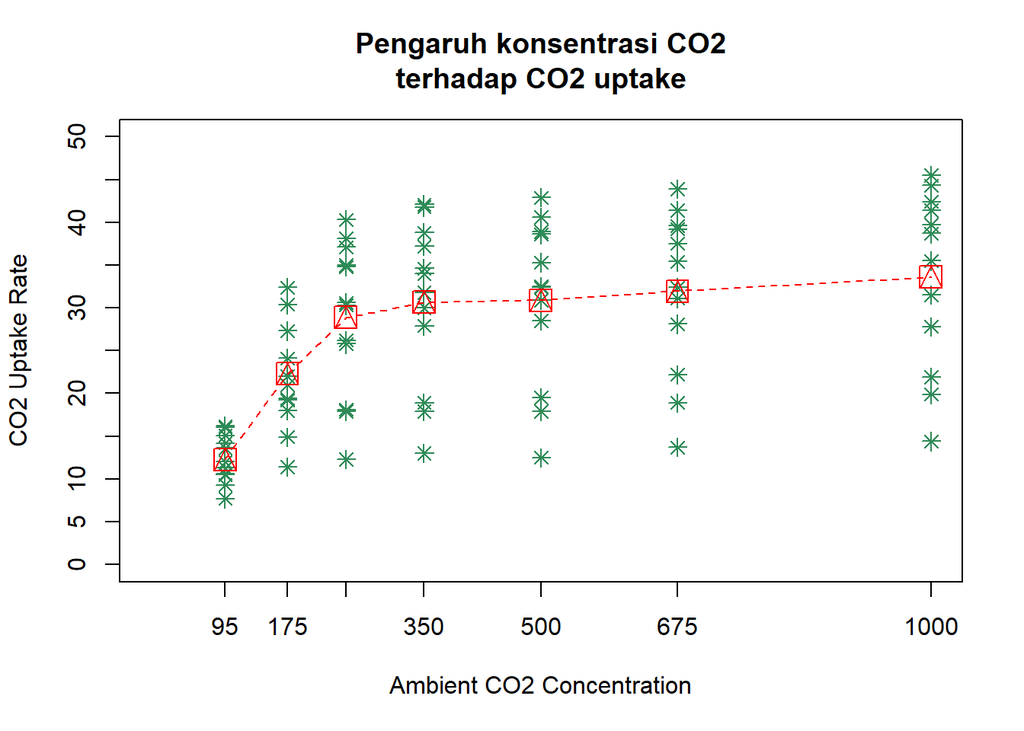

```r
axis(1,unique(df$conc))
axis(2,seq(0,50, by=5))
points(unique(df$conc), meanuptake, pch=14, cex=2,col="red")
lines(unique(df$conc), meanuptake, lty=2, col="red")
```

Plot 2,1

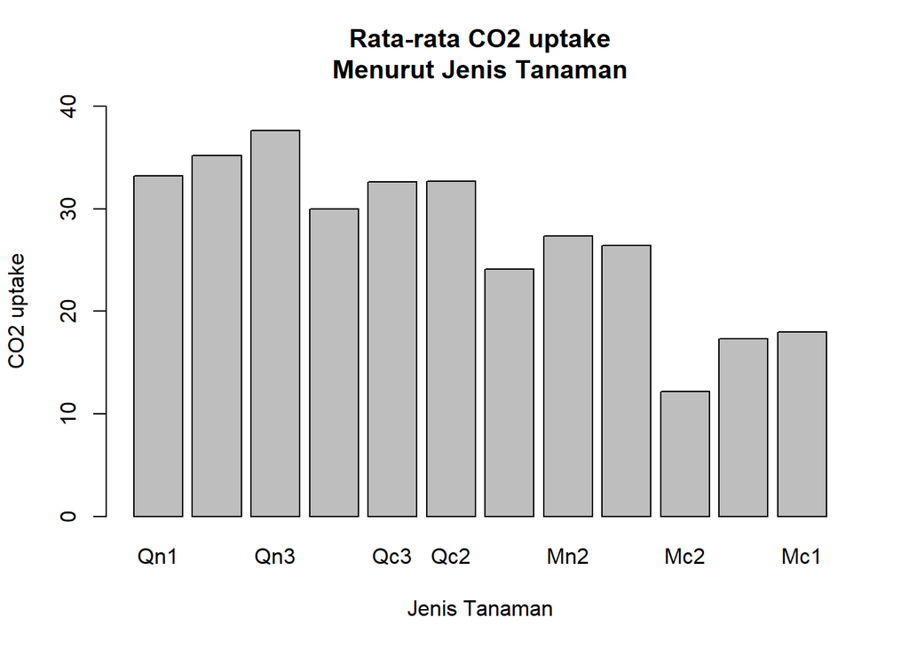

```r
aggr<-aggregate(uptake ~ Plant, data=df, FUN = mean)
barp<-setNames(aggr[,2],aggr[,1])
barplot(height = barp, main = "Rata-rata CO2 uptake\nMenurut Jenis Tanaman", xlab = "Jenis Tanaman", ylab="CO2 uptake", ylim=c(0,40))
```

Plot 2,2

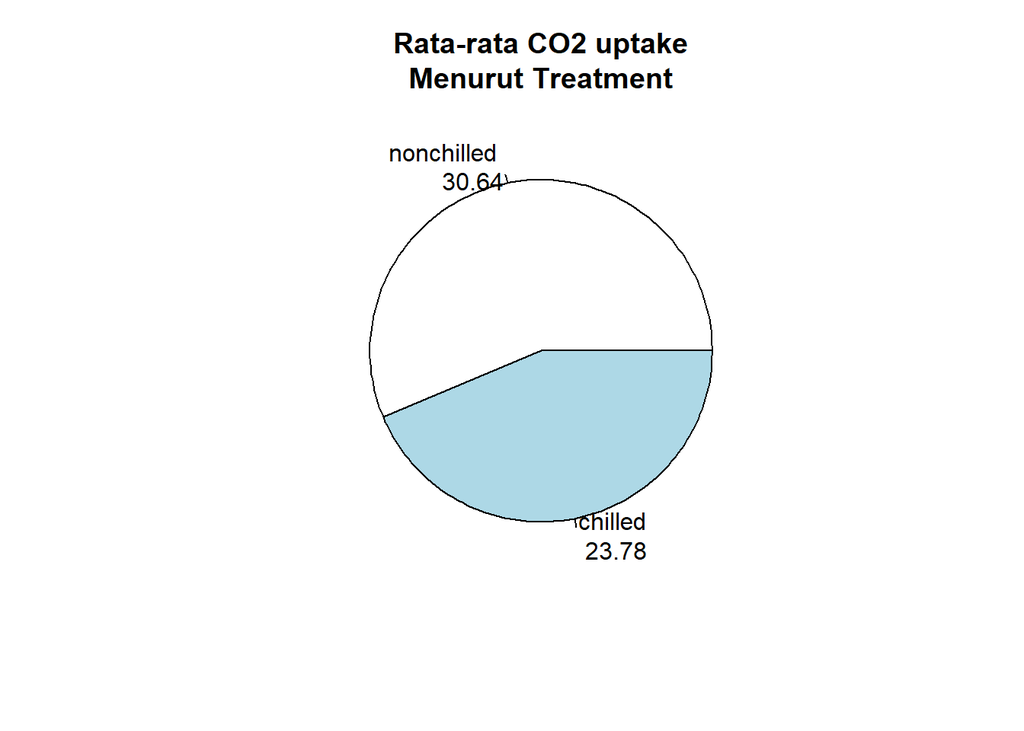

```r
aggr2<-aggregate(uptake ~ Treatment, data=df, FUN = mean)
piec<-setNames(aggr2[,2],paste(aggr2[,1], "\n", round(aggr2[,2], 2)))
pie(x = piec, main = "Rata-rata CO2 uptake\nMenurut Treatment")
```

Karena pada Quatro tidak dapat menampilkan seluruh plot dalam matriks 2 x 2, maka berikut plot hasil exportnya:

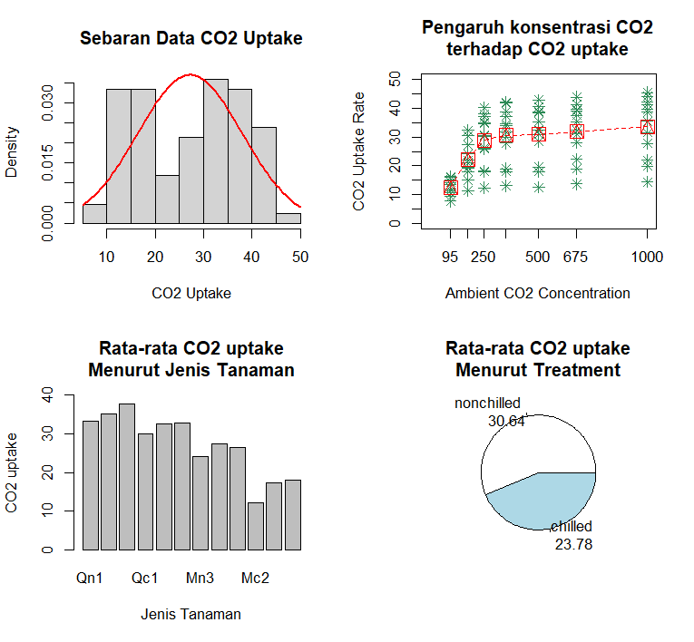

##### Poin 3

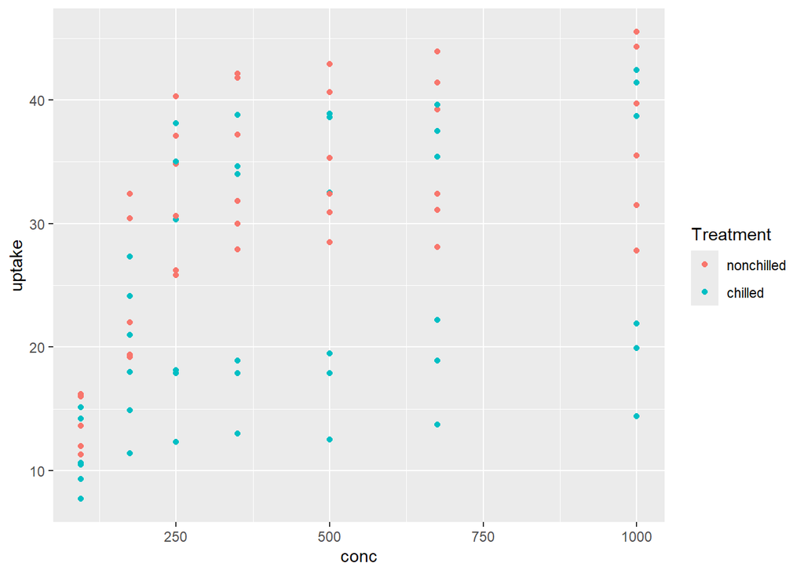

```r
library(ggplot2)
qplot(x = conc, y = uptake, data = df, color = Treatment)
```

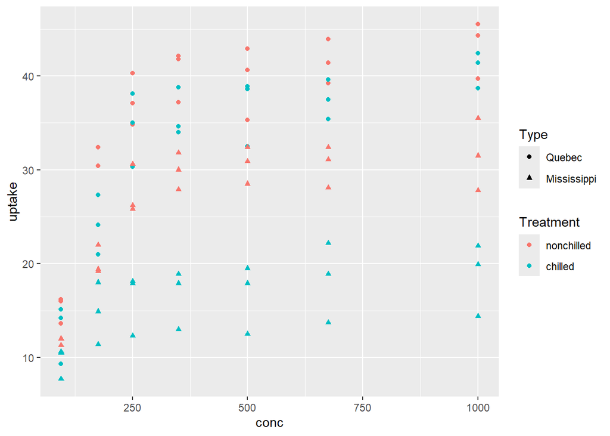

```r
gg<-ggplot(data = df, aes(x = conc, y = uptake, colour = Treatment, shape = Type))
gg1<-gg+geom_point()
gg1
```

##### Poin 4

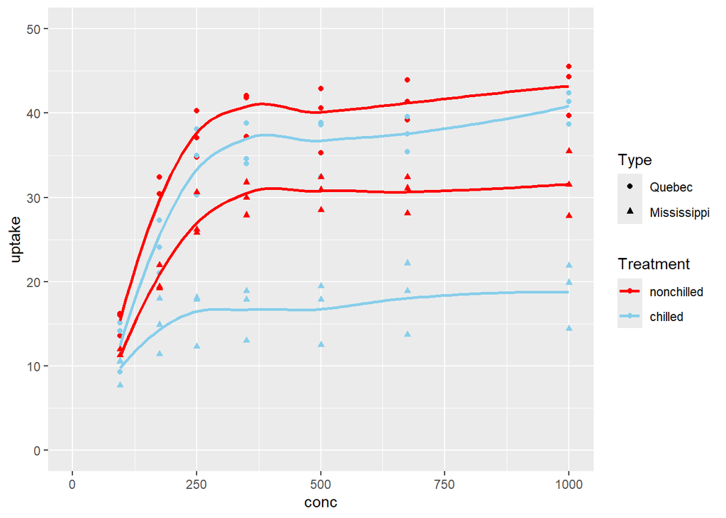

```r
gg2<-gg1+stat_smooth(method="loess", se = FALSE)+
  scale_color_manual(values = c("chilled" = "skyblue",
                                "nonchilled" = "red"))+
  coord_cartesian(xlim = c(0, 1000), ylim = c(0, 50))
gg2
```

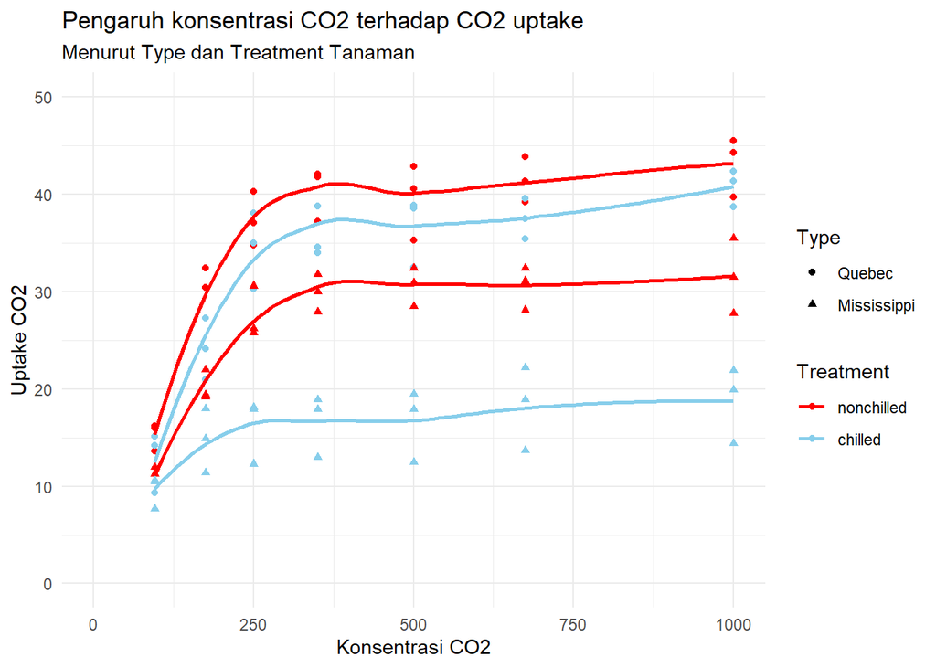

```r
gg2<- gg2 + labs(title = "Pengaruh konsentrasi CO2 terhadap CO2 uptake",
                 subtitle = "Menurut Type dan Treatment Tanaman",
                 x = "Konsentrasi CO2",
                 y = "Uptake CO2") +
  theme_minimal()
gg2
```

##### Poin 5

```r
ggsave(plot = gg2, filename = "co2_uptake_visualisasi.png")
```

Link hasil export setelah diunggah di Github: co2_uptake_visualisasi.png

##### Interpretasi

- Interpretasi mengenai hubungan antara konsentrasi CO₂ dan `uptake`

Uptake meningkat seiring naiknya konsentrasi CO2, tetapi hubungannya tidak linier atau cenderung logaritmik, dimana kenaikan uptake sangat signifikan pada konsentrasi CO2 rendah, kemudian kenaikan uptake melandai pada konsentrasi CO2 tinggi.

- Interpretasi perbedaan pola yang terlihat berdasarkan `Type` dan `Treatment.`

Tanaman `nonchilled` umumnya menunjukkan uptake lebih tinggi di seluruh rentang konsentrasi dibanding `chilled.`

Tipe `Quebec` biasanya menunjukkan uptake lebih tinggi dan mendekati landai lebih cepat dibanding `Mississippi`